# ggplot 막대그래프

### 막대그래프 (Bar Chart) 만들기

데이터의 크기를 막대의 길이로 표현한 그래프.  
집단간 차이를 표현할 때 주로 사용됨.

```r
library(dplyr)
```

```r
library(ggplot2)
df_mpg <- mpg %>%
  group_by(drv) %>%
  summarise(mean_hwy = mean(hwy))

df_mpg
```

```
## # A tibble: 3 x 2
##   drv   mean_hwy
##   <chr>    <dbl>
## 1 4         19.2
## 2 f         28.2
## 3 r         21
```

x 축에 범주를 나타내는 변수를 지정

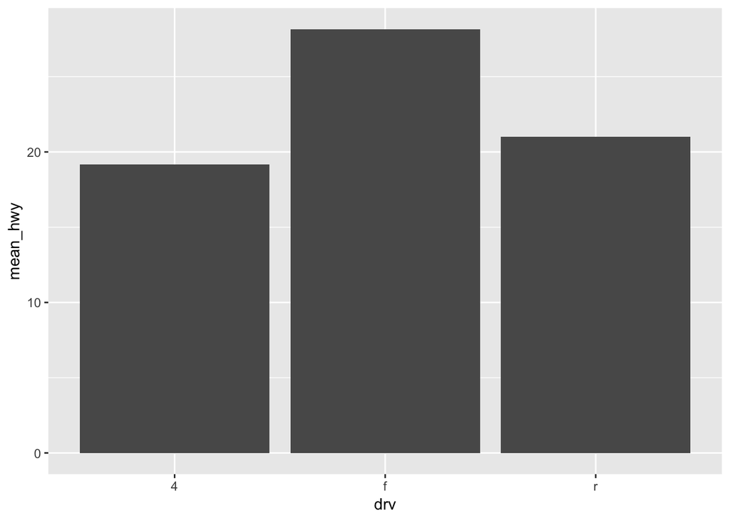

```r
ggplot(df_mpg, aes(x = drv, y = mean_hwy)) + geom_col()
```

#### 크기순으로 정렬하기

- 막대는 기본적으로 범주의 알파벳 순으로 정렬됨.
- reorder() 를 사용하면 막대를 값의 크기 순으로 정렬할 수 있음.
- reorder() 에 x축 변수와 정렬 기준으로 삼을 변수를 지정하면 됨. 정렬기준 앞에 - 기호를 붙이면 내림차순으로 정렬함.

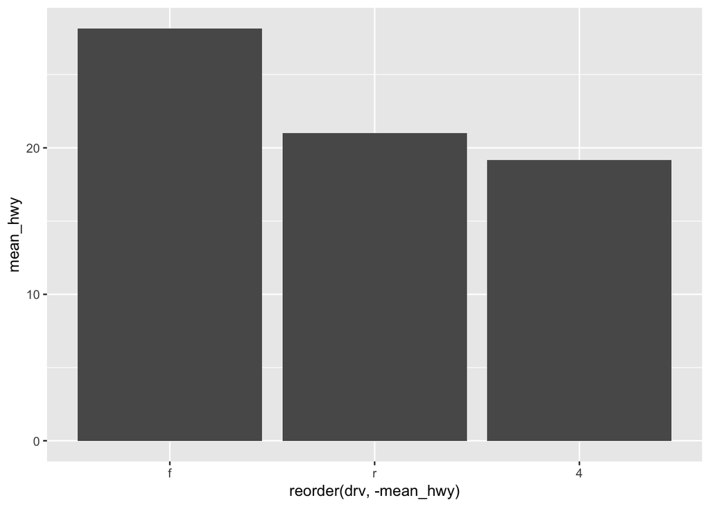

```r
ggplot(df_mpg, aes(x = reorder(drv, -mean_hwy), y = mean_hwy)) + geom_col()
```

### 빈도 막대그래프 그리기

빈도 막대그래프는 값의 개수(빈도)로 막대의 길이를 표현한 그래프.  
빈도 막대 그래프를 만들려면 y축 없이 x축만 지정하고, geom_col() 대신 geom_bar() 를 사용하면 됨.

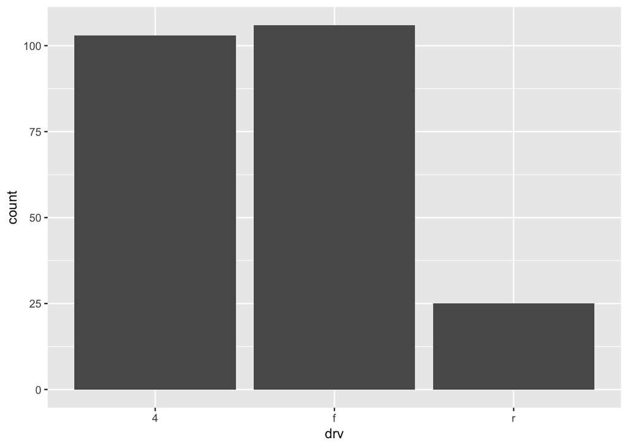

```r
ggplot(mpg, aes(x = drv)) + geom_bar()
```

x축에 연속변수르 지정하면 값의 분포를 파악할 수 있음.

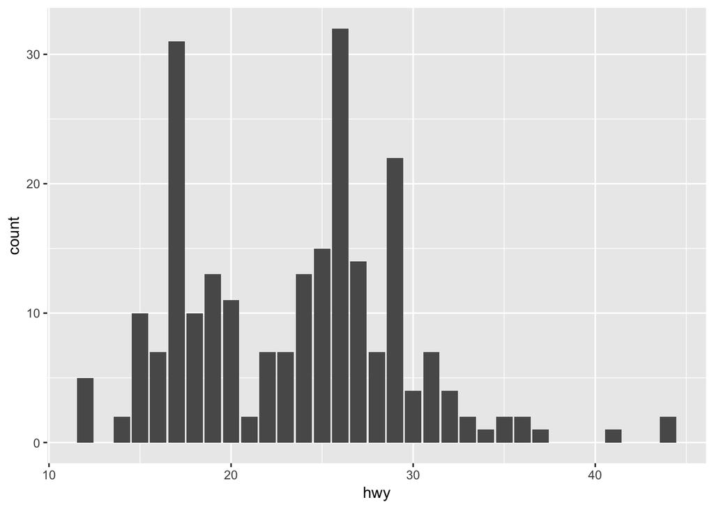

```r
ggplot(mpg, aes(x = hwy)) + geom_bar()
```

#### Q1.

```r
mpg <- as.data.frame((ggplot2::mpg))

df <- mpg %>%
  filter(class == "suv") %>%
  group_by(manufacturer) %>%
  summarise(mean.cty = mean(hwy)) %>%
  arrange(desc(mean.cty)) %>%
  head(5)
df
```

```
## # A tibble: 5 x 2
##   manufacturer mean.cty
##   <chr>           <dbl>
## 1 subaru           25
## 2 toyota           18.2
## 3 mercury          18
## 4 nissan           18
## 5 ford             17.8
```

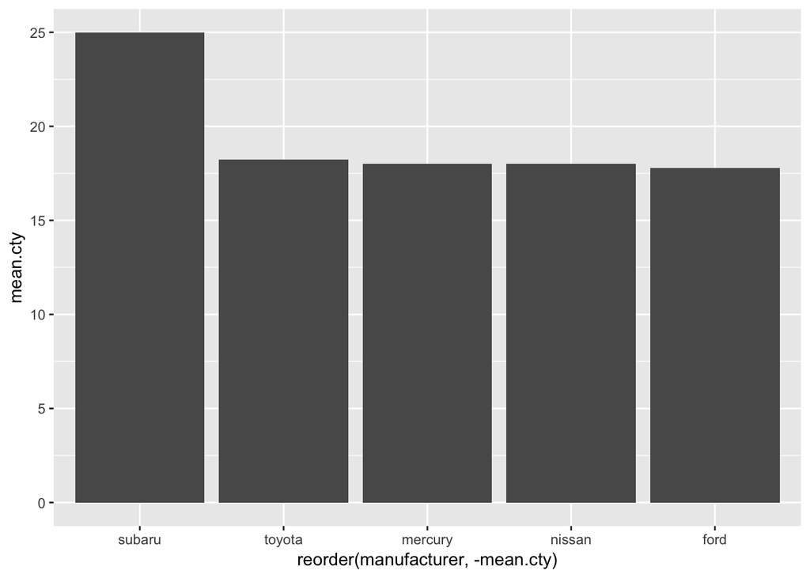

```r
ggplot(df, aes(x = reorder(manufacturer, -mean.cty), y = mean.cty)) + geom_col()
```

#### Q2.

자동차 중에서 어떤 class (자동차종류)가 가장 많은지 알아보려고 합니다. 자동차 종류별 빈도를 표현한 막대그래프를 만들어보세요.

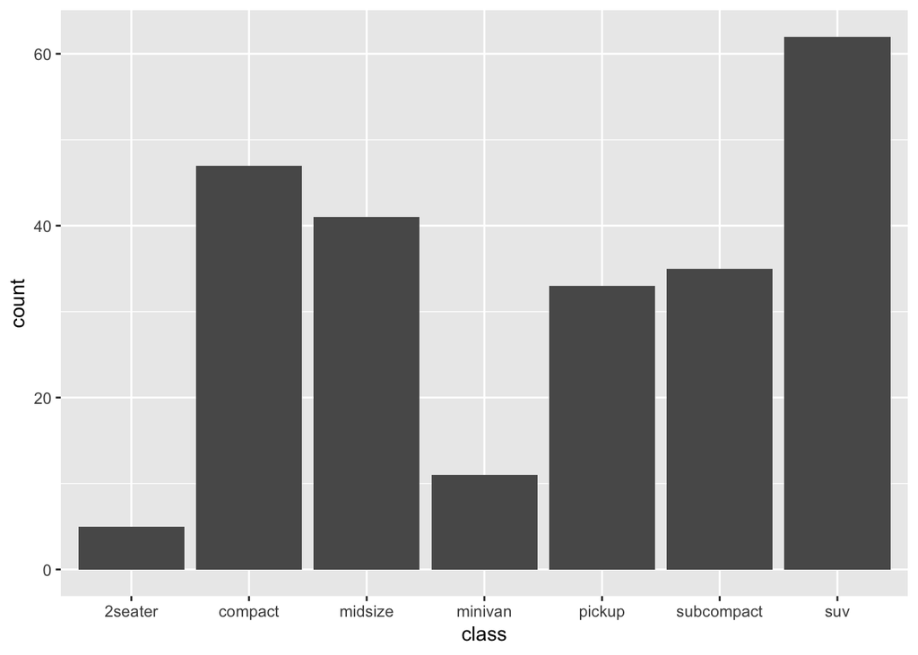

```r
ggplot(mpg, aes(x = class)) + geom_bar()
```

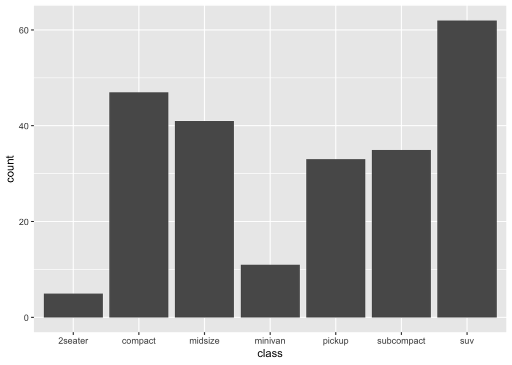

```r
ggplot(mpg, aes(x = class)) + geom_histogram(stat="count")
```

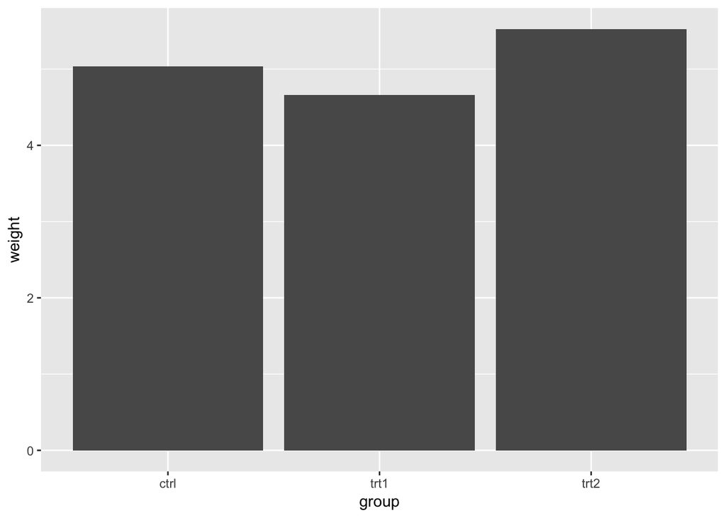

```r
library(gcookbook)
ggplot(pg_mean, aes(x = group, y = weight)) + geom_col()
```

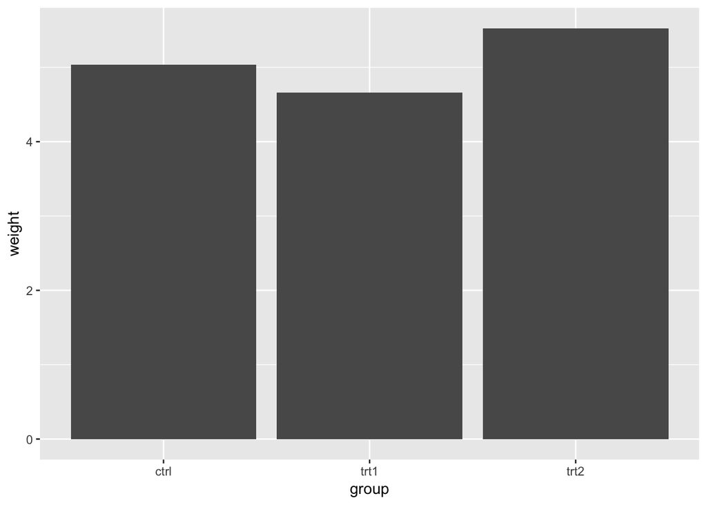

```r
library(gcookbook)
ggplot(pg_mean, aes(x = group, y = weight)) + geom_bar(stat = "identity")
```

#### 막대의 색상 채우기

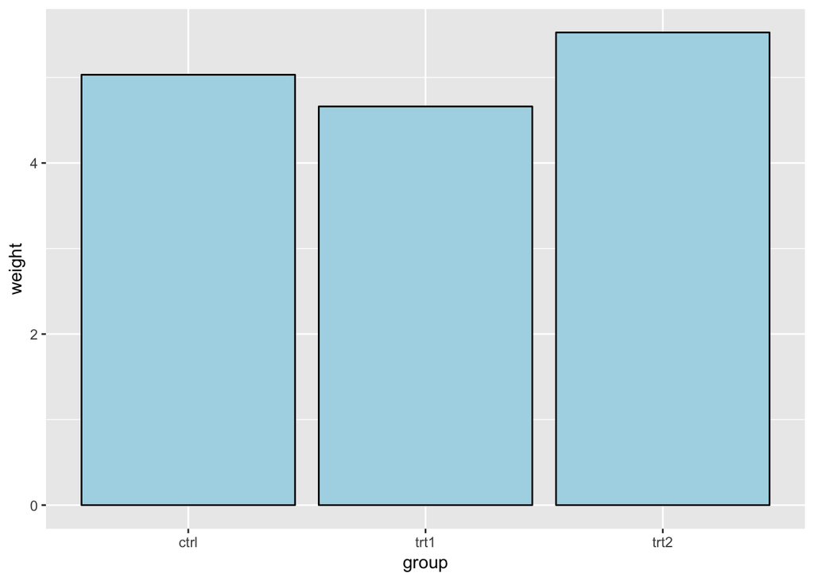

```r
ggplot(pg_mean, aes(x = group, y = weight)) +
  geom_col(fill = "lightblue", colour = "black")
```

#### 막대를 함께 묶기

- 두번째 변수를 기준으로 막대들을 묶음.
- fill 에 하나의 변수를 넣고 geom_bar(position = “dodge”) 로 설정한다.

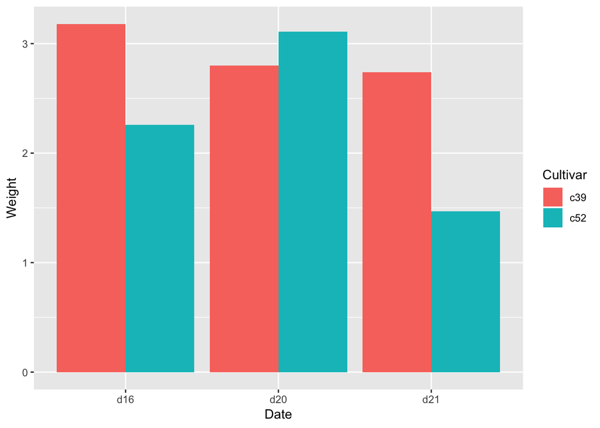

```r
ggplot(cabbage_exp, aes(x = Date, y = Weight, fill = Cultivar)) +
  geom_col(position = "dodge")
```

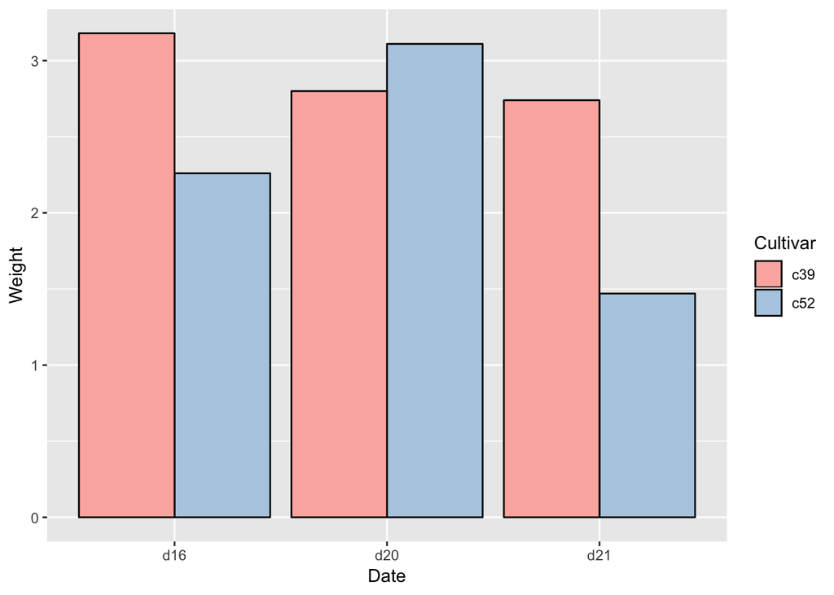

```r
ggplot(cabbage_exp, aes(x = Date, y = Weight, fill = Cultivar)) +
  geom_col(position = "dodge", colour = "black") +
  scale_fill_brewer(palette="Pastel1")
```

#### 막대그래프에 서로 다른 색상 입히기

```r
library(gcookbook)
upc <- subset(uspopchange, rank(Change) > 40)
upc
```

```
##             State Abb Region Change
## 3         Arizona  AZ   West   24.6
## 6        Colorado  CO   West   16.9
## 10        Florida  FL  South   17.6
## 11        Georgia  GA  South   18.3
## 13          Idaho  ID   West   21.1
## 29         Nevada  NV   West   35.1
## 34 North Carolina  NC  South   18.5
## 41 South Carolina  SC  South   15.3
## 44          Texas  TX  South   20.6
## 45           Utah  UT   West   23.8
```

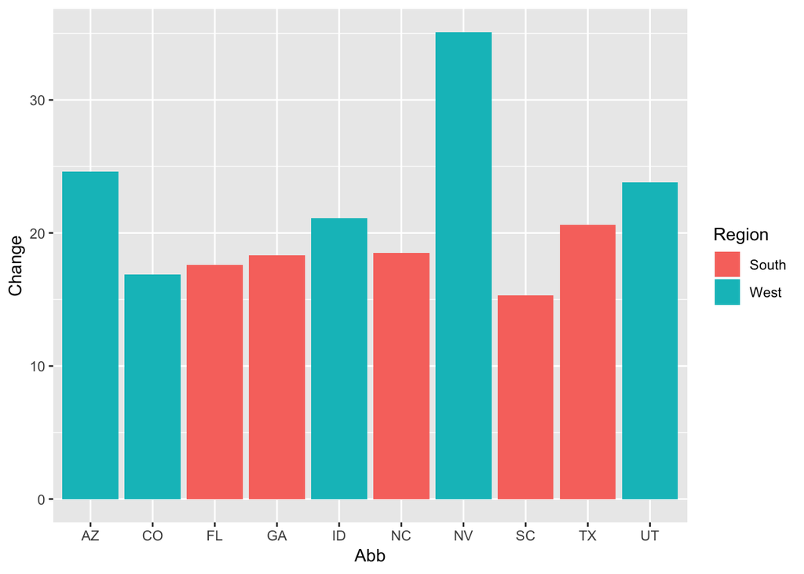

```r
ggplot(upc, aes(x = Abb, y = Change, fill = Region)) +
  geom_col()
```

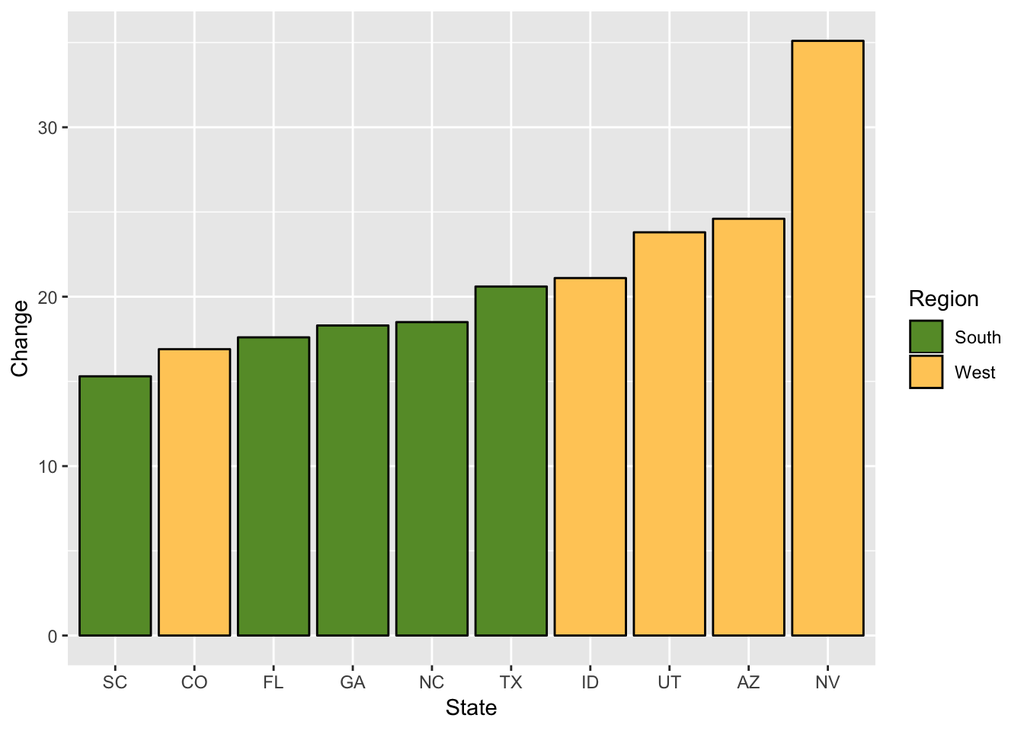

```r
ggplot(upc, aes(x = reorder(Abb, Change), y = Change, fill = Region)) +
  geom_col(colour = "black") +
  scale_fill_manual(values = c("#669933", "#FFCC66")) +
  xlab("State")
```

#### 음수와 양수 막대 다르게 색상 입히기

```r
library(gcookbook)
csub <- subset(climate, Source == "Berkeley" & Year >= 1900)
csub$pos <- csub$Anomaly10y >= 0
```

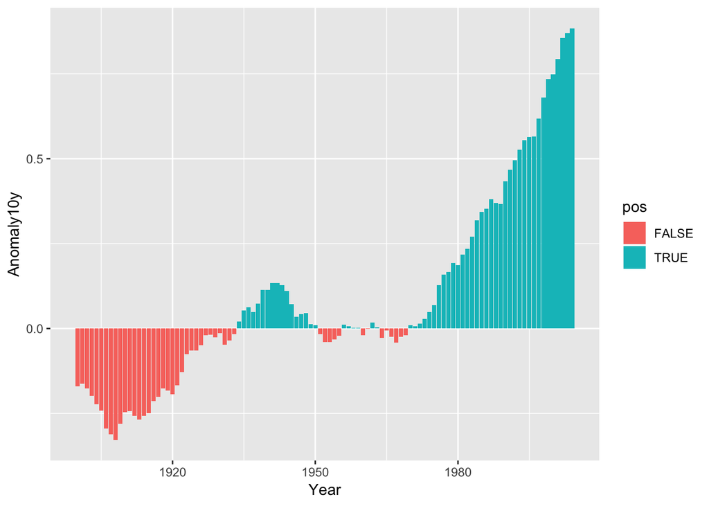

```r
ggplot(csub, aes(x = Year, y = Anomaly10y, fill = pos)) +
  geom_col()
```

scale_fill_manual() 을 사용해 색깔을 바꾸고, guide=FALSE 로 범례를 지움

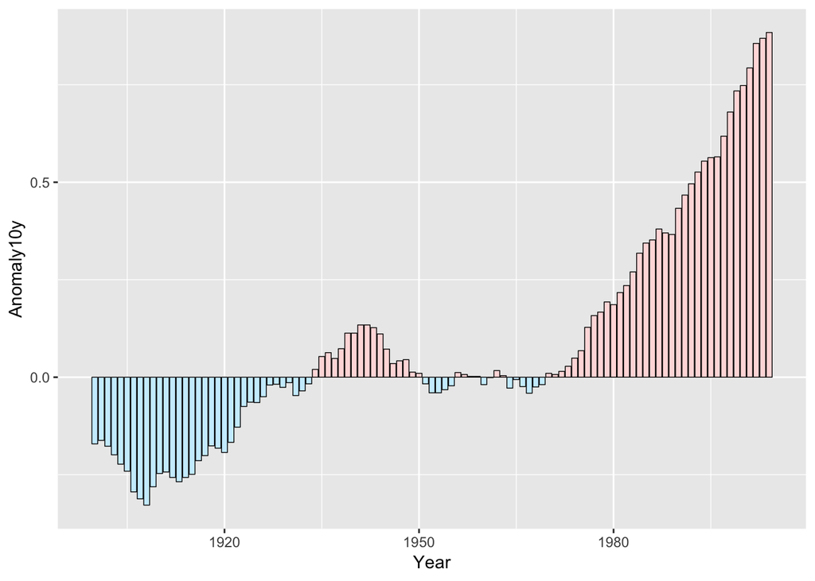

```r
ggplot(csub, aes(x = Year, y = Anomaly10y, fill = pos)) +
  geom_col(colour = "black", size = .25) +
  scale_fill_manual(values = c("#CCEEFF", "#FFDDDD"), guide = FALSE)
```

#### 막대의 너비 및 간격 조절하기

- 막대를 좁히거나 넓힐 때는 geom_bar() 의 width 를 설정

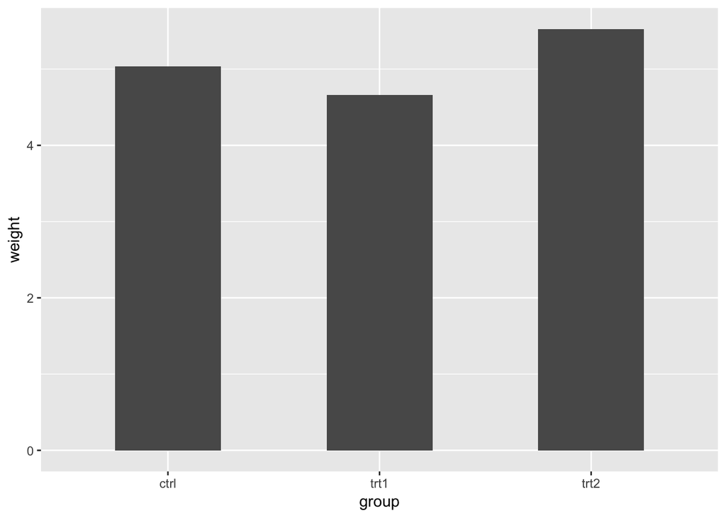

```r
library(gcookbook)
ggplot(pg_mean, aes(x = group, y = weight)) +
  geom_col(width = .5)
```

최대넓이 1

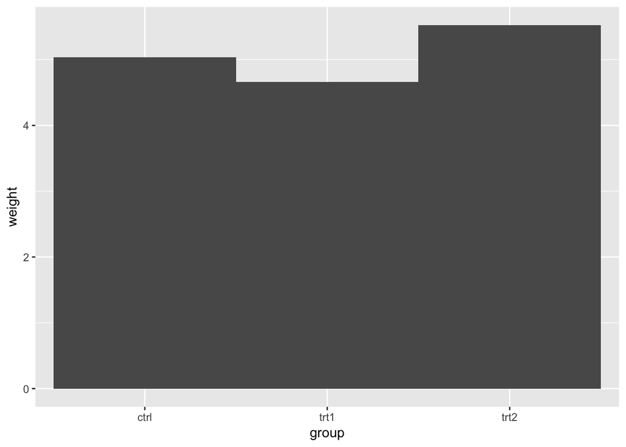

```r
library(gcookbook)
ggplot(pg_mean, aes(x = group, y = weight)) +
  geom_col(width = 1)
```

#### 누적막대그래프 그리기

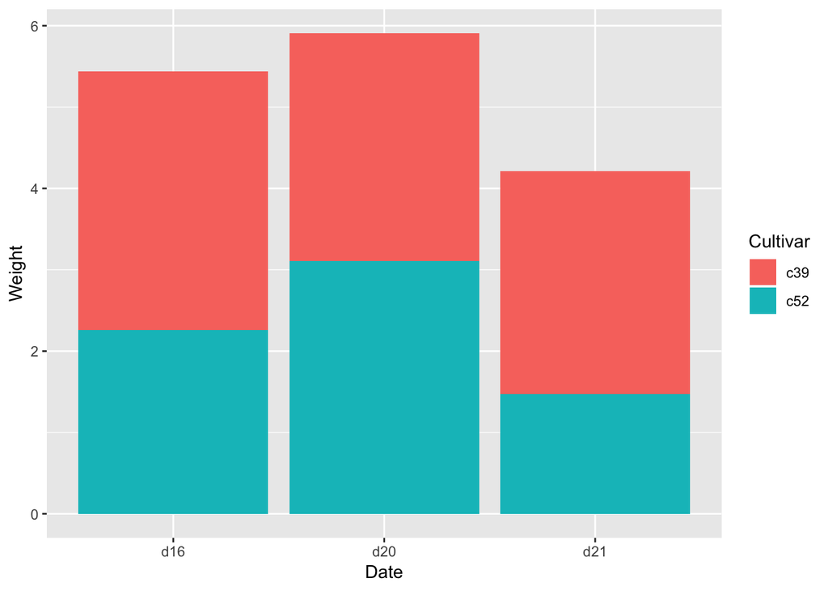

```r
ggplot(cabbage_exp, aes(x = Date, y = Weight, fill = Cultivar)) +
  geom_col()
```

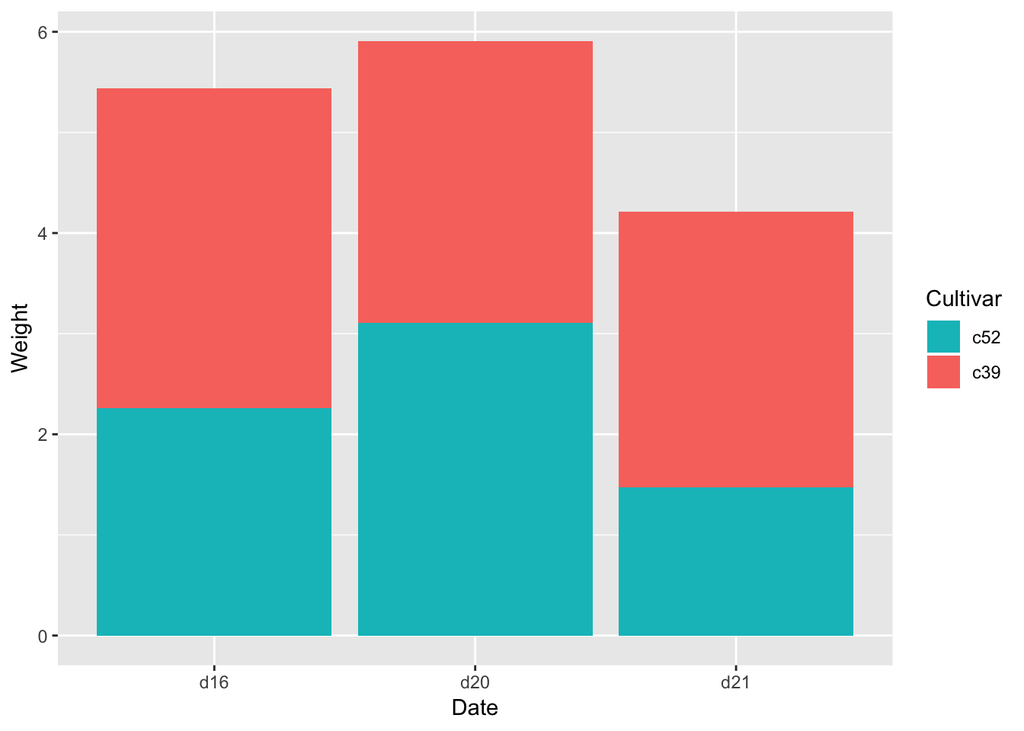

```r
ggplot(cabbage_exp, aes(x = Date, y = Weight, fill = Cultivar, order = desc(Cultivar))) +
  geom_col() +
  guides(fill = guide_legend(reverse = TRUE))
```

#### 비율 누적 막대 그래프 그리기

```r
library(dplyr)
ce <- cabbage_exp %>%
  group_by(Date) %>%
  mutate(percent_weight = Weight / sum(Weight) * 100)

ce
```

```
## # A tibble: 6 x 7
## # Groups:   Date [3]
##   Cultivar Date  Weight    sd     n     se percent_weight
##   <fct>    <fct>  <dbl> <dbl> <int>  <dbl>          <dbl>
## 1 c39      d16     3.18 0.957    10 0.303            58.5
## 2 c39      d20     2.8  0.279    10 0.0882           47.4
## 3 c39      d21     2.74 0.983    10 0.311            65.1
## 4 c52      d16     2.26 0.445    10 0.141            41.5
## 5 c52      d20     3.11 0.791    10 0.250            52.6
## 6 c52      d21     1.47 0.211    10 0.0667           34.9
```

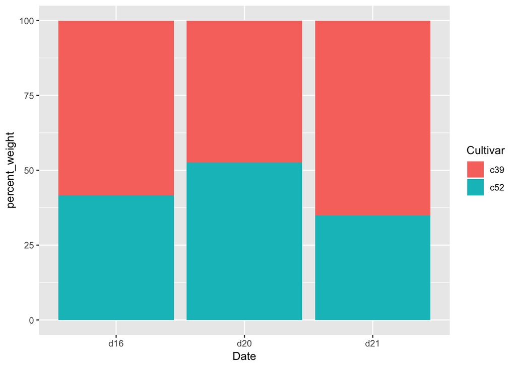

```r
ggplot(ce, aes(x = Date, y = percent_weight, fill = Cultivar)) +
  geom_col()
```

#### 막대그래프에 라벨 추가하기

그래프에 geom_text()를 추가. vjust(vertical justification) 을 설정함으로써 텍스트를 막대의 상단 위 아래로 움직일 수 있다.

- 막대의 위쪽선 하단

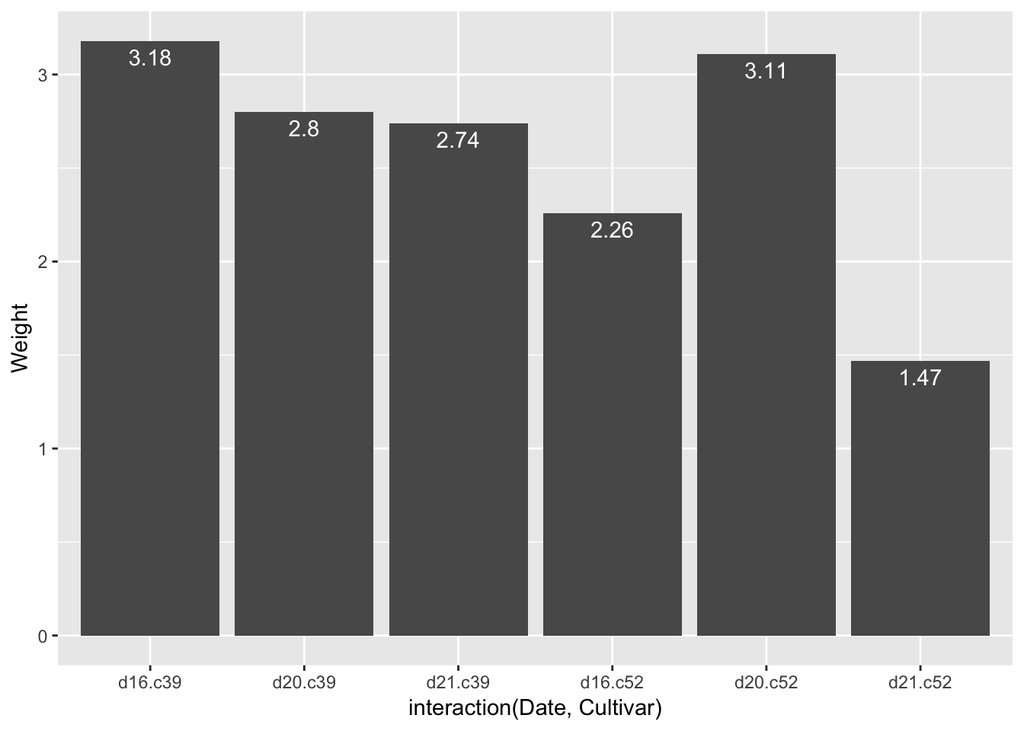

```r
ggplot(cabbage_exp, aes(x = interaction(Date, Cultivar), y = Weight)) +
  geom_col() +
  geom_text(aes(label = Weight), vjust = 1.5, color = "white")
```

- 막대의 위쪽선 상단

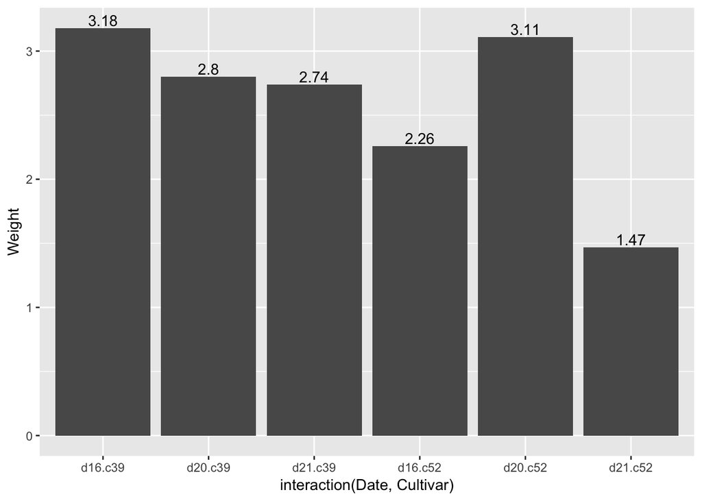

```r
ggplot(cabbage_exp, aes(x = interaction(Date, Cultivar), y = Weight)) +
  geom_col() +
  geom_text(aes(label = Weight), vjust = -0.2)
```

- 묶인 막대그래프 에서는 position=position_dodge()를 지정하고 묶음간 거리를 값으로 지정해야 함
- 기본설정은 0.9
- size 의 기본값은 5

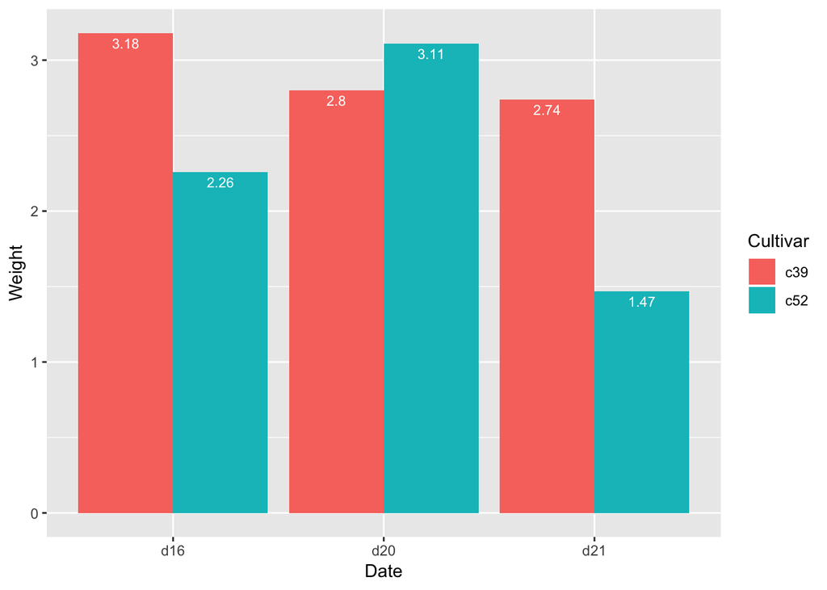

```r
ggplot(cabbage_exp, aes(x = Date, y = Weight, fill = Cultivar)) +
  geom_col(position = "dodge") +
  geom_text(aes(label = Weight), vjust = 1.5, color = "white",
            position = position_dodge(.9), size = 3)
```

- 누적막대 그래프의 라벨

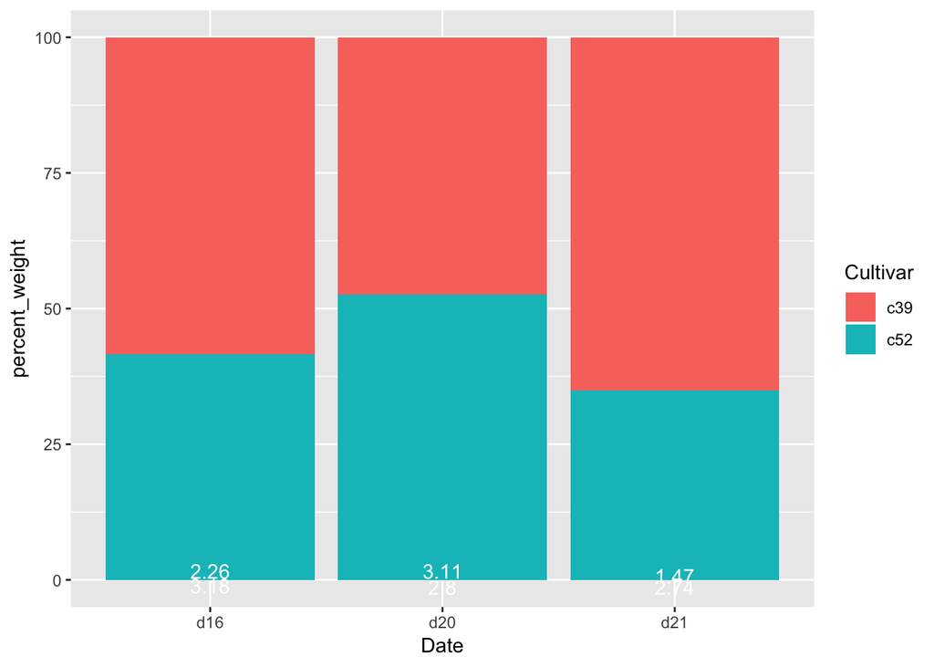

```r
ce <- cabbage_exp %>%
  group_by(Date) %>%
  mutate(percent_weight = Weight / sum(Weight) * 100)

ce <- ce %>%
  arrange(Date, Cultivar) %>%
  group_by(Date) %>%
  mutate(label_y = cumsum(Weight) - 0.5*Weight)

ggplot(ce, aes(x = Date, y = percent_weight, fill = Cultivar)) +
  geom_col() +
  geom_text(aes(y = label_y, label = Weight), vjust = 1.5, color = "white")
```